# IODS course project

Vilja Helminen

# Introduction to Open Data Science - Course Project

# About the project

*This course covers the basics of reproducible research with R, Rstudio, and Github. My Github repository can be found here: https://github.com/viljahe/IODS-project*

```r
date()
```

```
## [1] "Thu Nov 12 18:15:50 2020"
```

I found this course by browsing courses for doctoral students, trying to find something that would actually benefit me in some way: I’m interested in open science, and while I have been using R for some years, Git is something I’m not yet familiar with but have been wanting to learn for a while now. So this was a good opportunity to do just that.

I’m looking forward to learning how Git can make my research more open and more reproducible. I hope I can adapt things I learn from this course as a part of my workflow. Three things I’m most looking forward to/goals for myself for this course:

1. Be more familiar and more efficient with RMarkdown, figure out how RMarkdown could benefit my workflow
2. Get to know Github so that I understand it’s capabilities and it doesn’t seem quite so scary anymore
3. Figure out what *else* I should learn in the future: what are the next steps after this course, which tools or skills would benefit me the most

# Regression and model validation

This week we learned about data wrangling and linear regression. First, we created a data set to be used in the analyses below including creating some summary variables. Then we learned how to conduct a simple multivariate linear regression and how to assess the model diagnostics.

```r
# load the necessary packages and set scientific notation off

options(scipen = 999)

library("GGally")
library("ggplot2")
```

## Inspecting the data

First, let’s load the data set created for this exercise to R and inspect its dimension and structure using `dim()` and `str()`:

```r
learning2014 <- read.table("learning2014.txt")
dim(learning2014)
```

```
## [1] 166   7
```

```r
str(learning2014)
```

```
## 'data.frame':    166 obs. of  7 variables:
##  $ gender  : chr  "F" "M" "F" "M" ...
##  $ age     : int  53 55 49 53 49 38 50 37 37 42 ...
##  $ attitude: num  3.7 3.1 2.5 3.5 3.7 3.8 3.5 2.9 3.8 2.1 ...
##  $ points  : int  25 12 24 10 22 21 21 31 24 26 ...
##  $ deep    : num  3.58 2.92 3.5 3.5 3.67 ...
##  $ surf    : num  2.58 3.17 2.25 2.25 2.83 ...
##  $ stra    : num  3.38 2.75 3.62 3.12 3.62 ...
```

The data contains information from 166 students from an introductory statistics course. Data include participants’ gender and age, a measure of global attitudes towards statistics, participants’ scored points in the exam, and three variables which reflect deep learning, surface learning, and strategic learning. The three variables are the mean of several original items asking about participant’s learning approaches in each of the three categories, and the attitude variable is a mean of ten original variables asking about different attitudes towards statistics.

We can inspect the data and the associations between variables visually using the function `ggpairs()` and look at the most common descriptive statistics with the help of `summary()` to get a more complete grasp of the data.

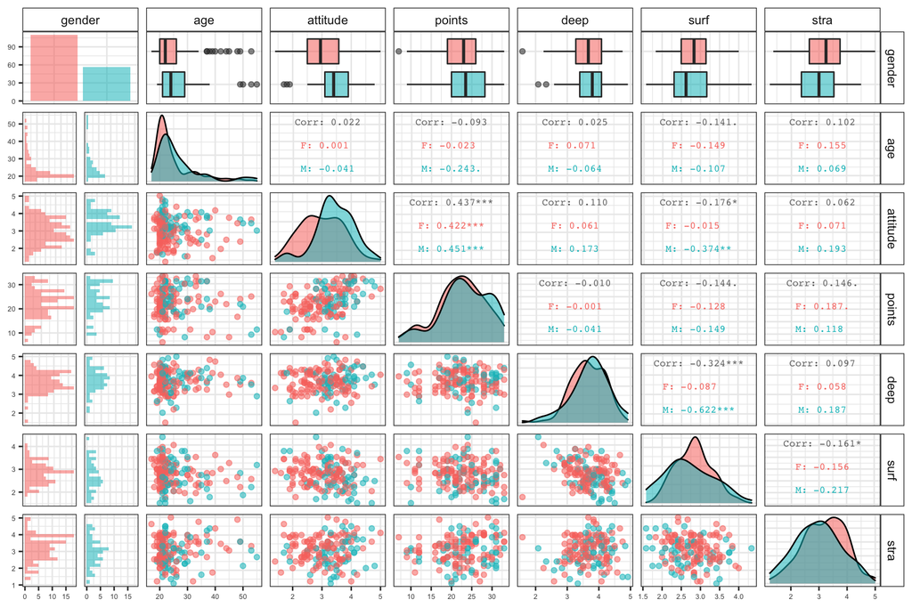

```r
p <- ggpairs(learning2014,
             mapping = aes(col = gender, alpha = 0.1),
             lower = list(combo = wrap("facethist", bins = 20)),
             upper = list(continuous = wrap("cor", size = 2.5)),
             ) +
  theme_bw() +
  theme(strip.background = element_rect(fill = "white"),
        axis.text.x = element_text(size=5),
        axis.text.y = element_text(size=5))
p
```

```r
summary(learning2014)
```

```
##     gender               age           attitude         points
##  Length:166         Min.   :17.00   Min.   :1.400   Min.   : 7.00
##  Class :character   1st Qu.:21.00   1st Qu.:2.600   1st Qu.:19.00
##  Mode  :character   Median :22.00   Median :3.200   Median :23.00
##                     Mean   :25.51   Mean   :3.143   Mean   :22.72
##                     3rd Qu.:27.00   3rd Qu.:3.700   3rd Qu.:27.75
##                     Max.   :55.00   Max.   :5.000   Max.   :33.00
##       deep            surf            stra
##  Min.   :1.583   Min.   :1.583   Min.   :1.250
##  1st Qu.:3.333   1st Qu.:2.417   1st Qu.:2.625
##  Median :3.667   Median :2.833   Median :3.188
##  Mean   :3.680   Mean   :2.787   Mean   :3.121
##  3rd Qu.:4.083   3rd Qu.:3.167   3rd Qu.:3.625
##  Max.   :4.917   Max.   :4.333   Max.   :5.000
```

The data seems to contain more women than men, and the participants are mostly under the age of 30. We can see that there are some differences between men and women on how the variables are distributed, most visibly in the global attitudes towards statistics where men have somewhat higher score on average, and the scores are distributed more evenly for women. Comparing the learning approaches, it would seem that deep learning scores skew a bit more towards the higher scores, whereas strategic scores are distributed more evenly around the middle. For men, the surface learning scores seem to be distributed more evenly than for women who have a more visible peak around the middle values of the variable.

There is a significant positive correlation between the global attitudes towards statistics and the exam score ($r = .437$), and this is also true for both gender groups. Attitudes towards statistics also seem to be slightly correlated with surface learning with more positive attitude being associated with lower score on surface learning ($r = -.176$), but upon closer inspection, it seems that there is no significant correlation for women, and for men the association is stronger than for all participants’ together ($r = -.374$). There is also an expected correlation between surface learning and deep learning, with higher scores on surface learning being associated with lower scores on deep learning ($r = -.324$), but surprisingly this effect is once again mostly driven by a strong association for men ($r = -.622$) whereas for women the learning approaches are not associated with each other.

## Linear regression

The associations between variables can be further examined using linear regression. For example, we can see how exam score is explained by the variables that have the strongest correlation with it: attitudes towards statistics, the surface learning approach, and the strategic learning approach.

```r
model1 <- lm(points ~ attitude + surf + stra, data = learning2014)
summary(model1)
```

```
##
## Call:
## lm(formula = points ~ attitude + surf + stra, data = learning2014)
##
## Residuals:
##      Min       1Q   Median       3Q      Max
## -17.1550  -3.4346   0.5156   3.6401  10.8952
##
## Coefficients:
##             Estimate Std. Error t value     Pr(>|t|)
## (Intercept)  11.0171     3.6837   2.991      0.00322 **
## attitude      3.3952     0.5741   5.913 0.0000000193 ***
## surf         -0.5861     0.8014  -0.731      0.46563
## stra          0.8531     0.5416   1.575      0.11716
## ---
## Signif. codes:  0 '***' 0.001 '**' 0.01 '*' 0.05 '.' 0.1 ' ' 1
##
## Residual standard error: 5.296 on 162 degrees of freedom
## Multiple R-squared:  0.2074, Adjusted R-squared:  0.1927
## F-statistic: 14.13 on 3 and 162 DF,  p-value: 0.00000003156
```

Based on the results of the regression, it would seem that more positive attitudes towards statistics is associated with higher scores on the exam ($B = 3.40, p <.001$). This means, that for each one point increase on the scale of attitudes, the exam score increases approximately 3.4 points. The two learning approaches included in the model do not seem to be associated with exam scores. They can therefore be removed from the model.

```r
# remove surf first as it's p-value is the higher of the two
model2 <- update(model1, ~. -surf)
summary(model2)
```

```
##
## Call:
## lm(formula = points ~ attitude + stra, data = learning2014)
##
## Residuals:
##      Min       1Q   Median       3Q      Max
## -17.6436  -3.3113   0.5575   3.7928  10.9295
##
## Coefficients:
##             Estimate Std. Error t value      Pr(>|t|)
## (Intercept)   8.9729     2.3959   3.745       0.00025 ***
## attitude      3.4658     0.5652   6.132 0.00000000631 ***
## stra          0.9137     0.5345   1.709       0.08927 .
## ---
## Signif. codes:  0 '***' 0.001 '**' 0.01 '*' 0.05 '.' 0.1 ' ' 1
##
## Residual standard error: 5.289 on 163 degrees of freedom
## Multiple R-squared:  0.2048, Adjusted R-squared:  0.1951
## F-statistic: 20.99 on 2 and 163 DF,  p-value: 0.000000007734
```

```r
# stra is still not significant, remove it as well
model3 <- update(model2, ~. -stra)
summary(model3)
```

```
##
## Call:
## lm(formula = points ~ attitude, data = learning2014)
##
## Residuals:
##      Min       1Q   Median       3Q      Max
## -16.9763  -3.2119   0.4339   4.1534  10.6645
##
## Coefficients:
##             Estimate Std. Error t value      Pr(>|t|)
## (Intercept)  11.6372     1.8303   6.358 0.00000000195 ***
## attitude      3.5255     0.5674   6.214 0.00000000412 ***
## ---
## Signif. codes:  0 '***' 0.001 '**' 0.01 '*' 0.05 '.' 0.1 ' ' 1
##
## Residual standard error: 5.32 on 164 degrees of freedom
## Multiple R-squared:  0.1906, Adjusted R-squared:  0.1856
## F-statistic: 38.61 on 1 and 164 DF,  p-value: 0.000000004119
```

With the surface learning approach first removed from the model, the p-value associated with strategic learning approach decreases, but the effect remains non-significant at the traditional significance level of $p < .05$. Removing both non-significant predictors from the model does not affect the association between attitudes towards statistics and exam scores greatly. More positive attitudes towards statistics are associated with higher exam scores, and the magnitude of the effect remains roughly the same ($B = 3.53, p <.001$). The multiple $R^2$ is a measure of goodness-of-fit of our model, i.e. it tells how well our model explains the variance of the dependent variable. From the $R^2$ we can infer that the model explains approximately 19% of the variance of the exam score.

## Model diagnostics

Let’s then examine how well our model meets the assumptions of linear regression. We can do this by inspecting diagnostic plots:

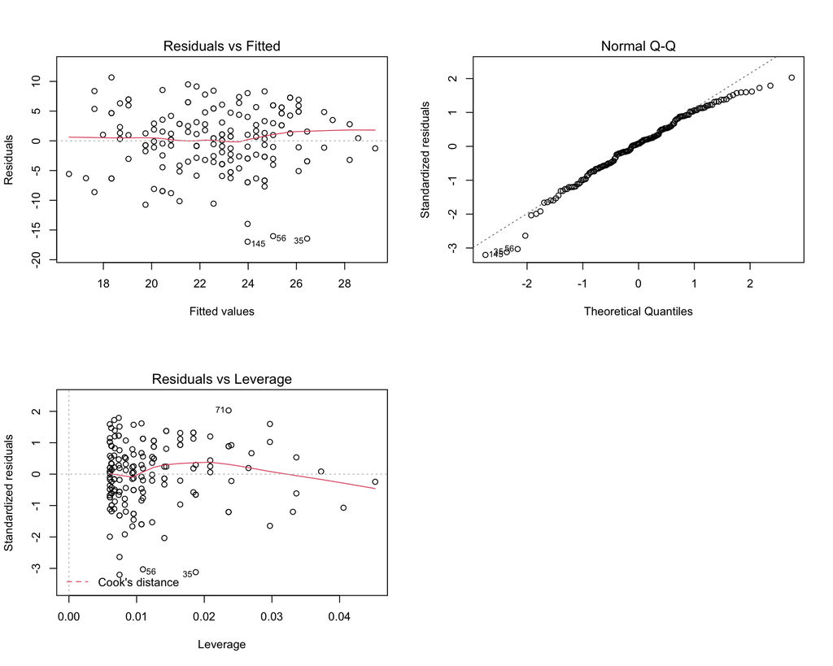

```r
# dev.new(width=7, height=20)
par(mfrow=c(2,2))
plot(model3, c(1, 2, 5))
```

In the first figure the residuals are compared to the predicted values of the model. The assumption of constant variance of errors is met as the errors are quite randomly spread. From the QQ-plot we can see, that the errors are reasonably normally distributed, following the dashed line quite well. In the third figure we see that no values have a very high leverage, so this assumption is met as well. Based on these, it can be concluded that there are no significant problems with the model.

# Logistic regression

This week was all about joining two datasets together wrangling and learning logistic regression. Again, in the data wrangling part we created a data set to be used in the analyses below merging two datasets together and creating some new variables. Then we learned how to conduct a logistic regression and assess the predictive power of the model.

```r
# load the necessary packages and set scientific notation off

options(scipen = 999)

library("dplyr")
library("tidyr")
library("ggplot2")
library("gridExtra")
library("Hmisc")
```

## First look at the data

This data consists information about students’ alcohol consumption, school performance in two subjects (mathematics and portuguese language), and some background variables relating to their social environment, family, and school. Data has been collected from two Portuguese schools. More information of the data used can be found here: https://archive.ics.uci.edu/ml/datasets/Student+Performance

```r
alc <- read.csv("alc.csv", sep=",", header=TRUE)

colnames(alc)
```

```
##  [1] "school"     "sex"        "age"        "address"    "famsize"
##  [6] "Pstatus"    "Medu"       "Fedu"       "Mjob"       "Fjob"
## [11] "reason"     "guardian"   "traveltime" "studytime"  "failures.m"
## [16] "schoolsup"  "famsup"     "paid.m"     "activities" "nursery"
## [21] "higher"     "internet"   "romantic"   "famrel"     "freetime"
## [26] "goout"      "Dalc"       "Walc"       "health"     "absences.m"
## [31] "G1.m"       "G2.m"       "G3.m"       "failures.p" "paid.p"
## [36] "absences.p" "G1.p"       "G2.p"       "G3.p"       "id.p"
## [41] "failures"   "paid"       "absences"   "G1"         "G2"
## [46] "G3"         "alc_use"    "high_use"
```

The data has been merged from two separate datasets, one specifically for math and other for portuguese language. The background variables are equal between the two original datasets, but the variables relating to school performance (failures, paid, absences, G1, G2, and G3) on these two subjects differ. These variables are the number of past class failures (failures), whether or not student has had extra paid classes (paid), number of absences (absences), and the first, second, and final grades (G1-G3, respectively). The final dataset used here therefore has three separate variables for each subject specific original variable: the two original variables denoted by either .p (for Portuguese) or .m (for math) and one that is the mean of the two original variables (without suffix).

My hypotheses are that more time spent on studying and higher grades are connected to low alcohol consumption, while higher number of absences and parents living apart are connected to high alcohol consumption.

## Distributions and relationships between variables

Let’s have a closer look at the chosen variables and how they relate to each other.

```r
# subset for only relevant variables
alc.sub <- subset(alc, select = c(studytime, absences, G3, Pstatus, high_use))

# see numerical summaries of variables
summary(alc.sub[(-4)])
```

```
##    studytime        absences            G3         high_use
##  Min.   :1.000   Min.   : 0.000   Min.   : 0.00   Mode :logical
##  1st Qu.:1.000   1st Qu.: 1.000   1st Qu.:10.00   FALSE:259
##  Median :2.000   Median : 3.000   Median :12.00   TRUE :111
##  Mean   :2.043   Mean   : 4.511   Mean   :11.52
##  3rd Qu.:2.000   3rd Qu.: 6.000   3rd Qu.:14.00
##  Max.   :4.000   Max.   :45.000   Max.   :18.00
```

```r
table(alc.sub["Pstatus"])
```

```
##
##   A   T
##  38 332
```

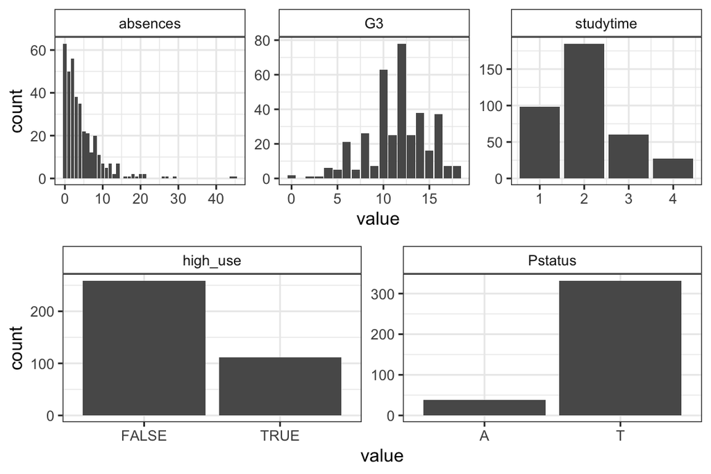

```r
# barplots for the distributions

# library(purrr)

numplot <- alc.sub[c("G3", "studytime", "absences")]  %>% gather() %>% ggplot(aes(as.numeric(value))) + facet_wrap("key", scales = "free") + geom_bar() + xlab("value") + theme_bw() + theme(strip.background = element_rect(fill = "white"))


discplot <- alc.sub[c("Pstatus", "high_use")]  %>% gather() %>% ggplot(aes(value)) + facet_wrap("key", scales = "free") + geom_bar() + theme_bw() + theme(strip.background = element_rect(fill = "white"))

grid.arrange(numplot, discplot, nrow=2)
```

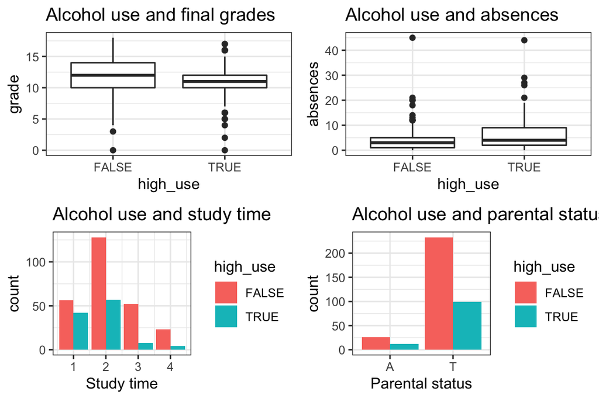

```r
# box plots for alcohol use vs. continuous variables

box1 <- ggplot(alc.sub, aes(x = high_use, y = G3)) +
  geom_boxplot() +
  ylab("grade") +
  ggtitle("Alcohol use and final grades") +
  theme_bw()

box2 <- ggplot(alc.sub, aes(x = high_use, y = absences)) +
  geom_boxplot() +
  ylab("absences") +
  ggtitle("Alcohol use and absences") +
  theme_bw()

# bar plots for alcohol use vs. discrete variables

bar1 <- alc.sub %>% ggplot(aes(x = studytime, fill = high_use)) +
  geom_bar(position = "dodge") +
  xlab("Study time") +
  ggtitle("Alcohol use and study time") +
  theme_bw()

bar2 <- alc.sub %>% ggplot(aes(x = Pstatus, fill = high_use)) + geom_bar(position = "dodge") +
  xlab("Parental status") +
  ggtitle("Alcohol use and parental status") +
  theme_bw()


# draw the plots

grid.arrange(box1, box2, bar1, bar2, ncol=2)
```

From the initial glance it doesn’t seem like alcohol use and mean of the final grades or number of absences are connected. The study time per week seems to be a bit lower for those whose alcohol consumption is high, and those whose parents live apart might be overrepresented in high alcohol users as well, although as the number of parents living apart in this data is very low it’s hard to draw any definite conclusions based on these figures alone.

```r
# correlations for numerical variables

corrs <- rcorr(as.matrix(alc.sub[(-4)]))
corrs
```

```
##           studytime absences    G3 high_use
## studytime      1.00    -0.12  0.17    -0.21
## absences      -0.12     1.00 -0.10     0.22
## G3             0.17    -0.10  1.00    -0.13
## high_use      -0.21     0.22 -0.13     1.00
##
## n= 370
##
##
## P
##           studytime absences G3     high_use
## studytime           0.0254   0.0007 0.0000
## absences  0.0254             0.0484 0.0000
## G3        0.0007    0.0484          0.0112
## high_use  0.0000    0.0000   0.0112
```

```r
# crosstabs for parental status and high use

table(alc.sub[c("Pstatus", "high_use")])
```

```
##        high_use
## Pstatus FALSE TRUE
##       A    26   12
##       T   233   99
```

The proportion of high alcohol users in both parental residential status groups is approximately the same, which does not support my hypothesis.

## Logistic regression

We can then use logistic regression to see if the results support my hypotheses.

```r
# first, specify studytime as factor as it is actually a categorical variable
alc.sub$studytime <- as.factor(alc.sub$studytime)

# specify model
model1 <- glm(high_use ~ studytime + absences + G3 + Pstatus, data = alc.sub, family = "binomial")

# print summary
modelsum1 <- summary(model1)

modelsum1
```

```
##
## Call:
## glm(formula = high_use ~ studytime + absences + G3 + Pstatus,
##     family = "binomial", data = alc.sub)
##
## Deviance Residuals:
##     Min       1Q   Median       3Q      Max
## -2.1429  -0.8596  -0.6513   1.1840   2.1990
##
## Coefficients:
##             Estimate Std. Error z value Pr(>|z|)
## (Intercept) -0.22075    0.62094  -0.356 0.722211
## studytime2  -0.46568    0.26686  -1.745 0.080987 .
## studytime3  -1.36077    0.44121  -3.084 0.002041 **
## studytime4  -1.28496    0.58511  -2.196 0.028086 *
## absences     0.07614    0.02311   3.294 0.000986 ***
## G3          -0.05500    0.03682  -1.494 0.135216
## PstatusT     0.13698    0.40095   0.342 0.732632
## ---
## Signif. codes:  0 '***' 0.001 '**' 0.01 '*' 0.05 '.' 0.1 ' ' 1
##
## (Dispersion parameter for binomial family taken to be 1)
##
##     Null deviance: 452.04  on 369  degrees of freedom
## Residual deviance: 416.24  on 363  degrees of freedom
## AIC: 430.24
##
## Number of Fisher Scoring iterations: 4
```

```r
# retrieve odds ratios, confidence intervals and p-values
OR <- coef(model1) %>% exp()
CI <- confint(model1) %>% exp()
p <- coef(modelsum1)[,4]

# print table of odds ratios, confidence intervals and p-values
cbind(OR, CI, p) %>% round(3)
```

```
##                OR 2.5 % 97.5 %     p
## (Intercept) 0.802 0.233  2.684 0.722
## studytime2  0.628 0.372  1.061 0.081
## studytime3  0.256 0.102  0.585 0.002
## studytime4  0.277 0.076  0.797 0.028
## absences    1.079 1.034  1.132 0.001
## G3          0.946 0.880  1.017 0.135
## PstatusT    1.147 0.535  2.608 0.733
```

The hypotheses regarding study time and absences was confirmed, but the results don’t support the hypotheses about final grades and parental residential status being associated with alcohol use.

## Predictive power of the model

```r
model2 <- update(model1,.~. -G3 -Pstatus)
summary(model2)
```

```
##
## Call:
## glm(formula = high_use ~ studytime + absences, family = "binomial",
##     data = alc.sub)
##
## Deviance Residuals:
##     Min       1Q   Median       3Q      Max
## -2.1907  -0.8577  -0.7137   1.1984   2.1174
##
## Coefficients:
##             Estimate Std. Error z value Pr(>|z|)
## (Intercept) -0.69160    0.23897  -2.894 0.003802 **
## studytime2  -0.50842    0.26455  -1.922 0.054631 .
## studytime3  -1.43763    0.43660  -3.293 0.000992 ***
## studytime4  -1.36272    0.58234  -2.340 0.019279 *
## absences     0.07788    0.02305   3.379 0.000727 ***
## ---
## Signif. codes:  0 '***' 0.001 '**' 0.01 '*' 0.05 '.' 0.1 ' ' 1
##
## (Dispersion parameter for binomial family taken to be 1)
##
##     Null deviance: 452.04  on 369  degrees of freedom
## Residual deviance: 418.70  on 365  degrees of freedom
## AIC: 428.7
##
## Number of Fisher Scoring iterations: 4
```

```r
# predict() the probability of high_use
probabilities <- predict(model1, type = "response")

# add the predicted probabilities to 'alc'
alc.sub <- mutate(alc.sub, probability = probabilities)

# use the probabilities to make a prediction of high_use
alc.sub <- mutate(alc.sub, prediction = ifelse(probability > 0.5, T , F))

# 2x2 cross table of alcohol use vs. the predictions
table(high_use = alc.sub$high_use, prediction = alc.sub$prediction)
```

```
##         prediction
## high_use FALSE TRUE
##    FALSE   247   12
##    TRUE     93   18
```

From the crosstabulation, we can see that the majority fall into the category where both predicted and actual alcohol use was low. Of the actual high alcohol users, most were predicted to be low alcohol users. All together, 93 persons were wrongly classified as low alcohol users, and 12 persons were wrongly classified as high alcohol users. This is not very surprising, given that the number belonging to each category in our data was very unequal, with most students being low alcohol users.  
We can also examine predictions and actual alcohol use visually by drawing a scatterplot, and calculate the percentage of wrongly categorized individuals:

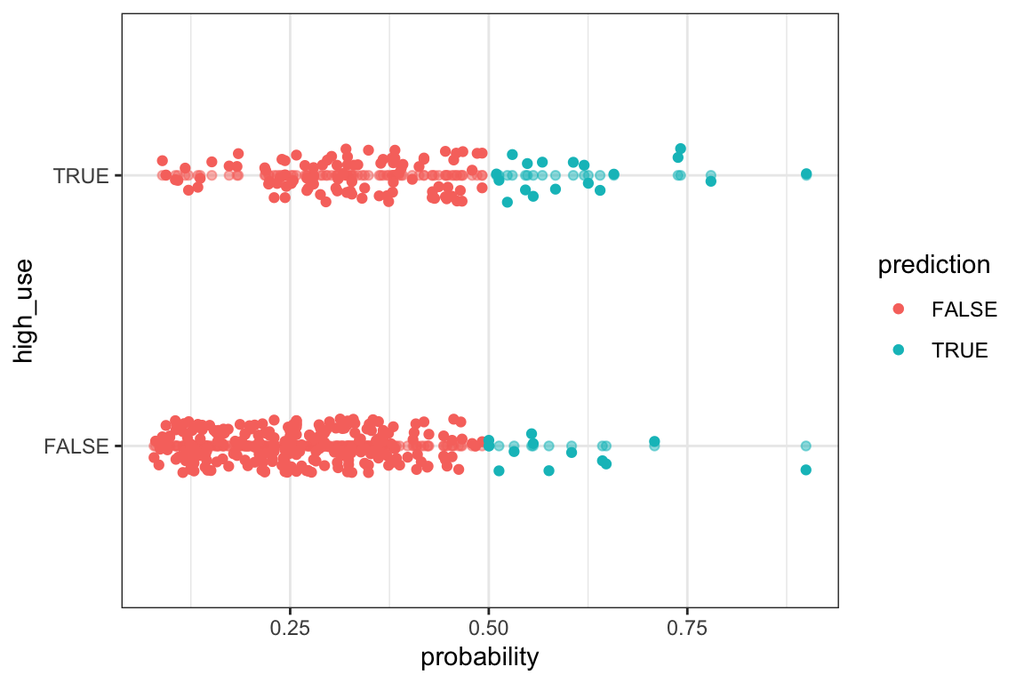

```r
# explore the predictions graphically
g.pred <- ggplot(alc.sub, aes(x = probability, y = high_use, col = prediction))
g.pred + geom_point(alpha = 0.5) + geom_jitter(height=0.1) + theme_bw()
```

```r
# calculate and print the total proportion of wrong classifications
prop_wrong <- function(class, prob) {
  n_wrong <- abs(class - prob) > 0.5
  perc <- sum(n_wrong)/length(class) * 100
  print(paste(round(perc,2), "% classified wrong"))
}

prop_wrong(class = alc.sub$high_use, prob = alc.sub$probability)
```

```
## [1] "28.38 % classified wrong"
```

The percentage of wrongly categorized individuals based on our model is 28.38 %. Although this number is quite high, it is notably better than simply guessing which would result in approximately 50% wrong guesses.

(more chapters to be added similarly as we proceed with the course!)